# Graphical EDA I: Continuous Data Presentation

Alexandra Văcaru (Gr 405)  
Ana-Maria Olteanu (Gr 405)  
Mara Chițimuș (Gr 405)

04 December 2021

# Cuprins

**1. Interpretarea variabilelor continue**

*1.1 Definiție și proprietăți*

*1.2 Reprezentarea variabilelor continue cu ajutorul graficelor*

*1.3 Exemple*

**2. Relații între variabile continue**

*2.1 Scatterplots*

*2.2 Modelarea și testarea relațiilor dintre variabile*

*2.3 Exemple*

*2.4 Adăugare de modele: linii și smooths*

*2.5 Compararea grupurilor din scatterplot*

*2.6 Matrice ale scatterplot-urilor (sploms)*

**3. Investigarea datelor continue multivariate**

*3.1 Diagramă de coordonate paralele (pcp)*

*3.2 Interpretarea rezultatelor de clustering*

*3.3 Exemple*

# 1.1 Definiție și proprietăți

- Definiție
  - O **variabilă continuă** este o variabilă care poate lua un număr infinit de valori numerice între două valori date, chiar dacă aceste două valori sunt aproape arbitrare.
  - Pentru a reprezenta distribuția datelor unei variabile continue sunt folosite mai multe tipuri de grafice, toate având același scop: să reprezinte caracteristicile importante ale datelor.
- Proprietăți
  - **asymmetry (asimetrie)** = distribuiția este înclinată spre dreapta sau spre stânga (exemplu: distribuția veniturilor)
  - **outliers (valori aberante)** = exista una sau mai multe valori care sunt departe de restul datelor
  - **multimodality** = distribuția are mai mult de un vârf (exemplu: date despre Old Faithful geyser)
  - **gaps (goluri)** = există intervale unde nu sunt înregistrate date (exemplu: notele de la examen)
  - **heaping** = unele valori apar foarte des (exemplu: greutatea bebelușilor)
  - **rounding** = conțin doar anumite valori (exemplu: distribuția vârstelor - numere întregi)
  - **impossibilities (valori imposibile)** = valori în afara intervalului fezabile (exemplu: vârste negative)
  - **errors (erori)** = valori care par greșite dintr-un motiv sau altul (exemplu: șoferi cu vârsta sub 16 ani)

# 1.2: Reprezentarea variabilelor continue cu ajutorul graficelor

- **histograma** = gruparea datelor în intervale și desenarea unei bare pentru fiecare interval
- **boxplot** = afișează valori aberante individuale și statistici robuste pentru date (folosit și pentru compararea distribuțiilor între subgrupuri)
- **dotplot** = afișează fiecare punct individual (folosit pentru a găsi goluri)
- **rugplot** = afișează fiecare punct individual reprezentat ca o linie (folosit de obicei împreună cu alte grafice)
- **density estimate** = reprezentarea grafică a unei densități estimative a distribuției variabilei
- **distribution estimate** = reprezentarea grafică a unei funcții de distribuție
- **Q-Q plot**

# 1.3 Exemple

*1.3.1 Înălțimi copii și părinți*

Pentru exemplele următoare este folosit setul de date *Galton* din pachetul *UsingR*, care conține *înălțimea medie a părinților* și *înalțimea copiilor*.

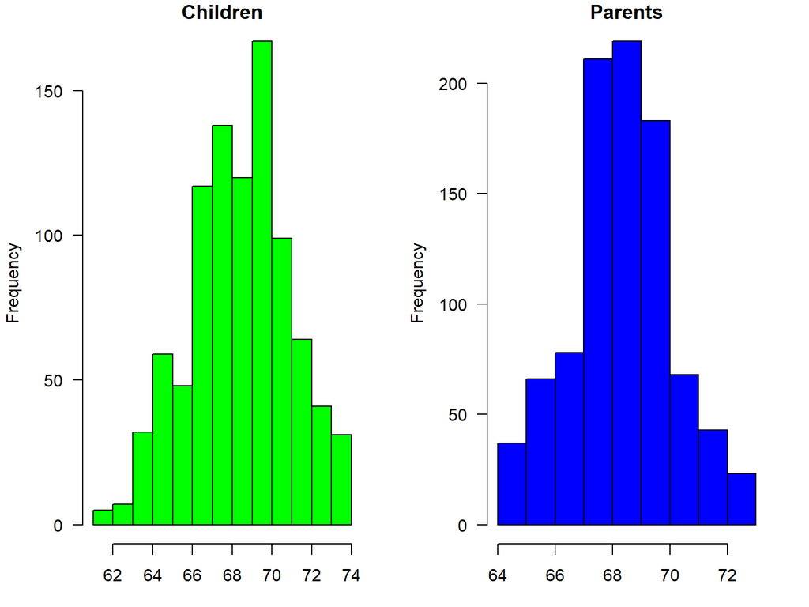

În histogramele de mai sus se observă că pe orizontală sunt figurate *înălțimile* (inch), iar pe verticală este figurată *frecvența* (numărul de copii/părinți care au o anumită înălțime). Deoarece graficele sunt desenate separat, scalarea este diferită, ceea ce face compararea mai dificilă. Ambele distribuții sunt aproximativ **simetrice**, observându-se un interval mai larg pentru copii. Putem spune că nu sunt prezente valori aberante.

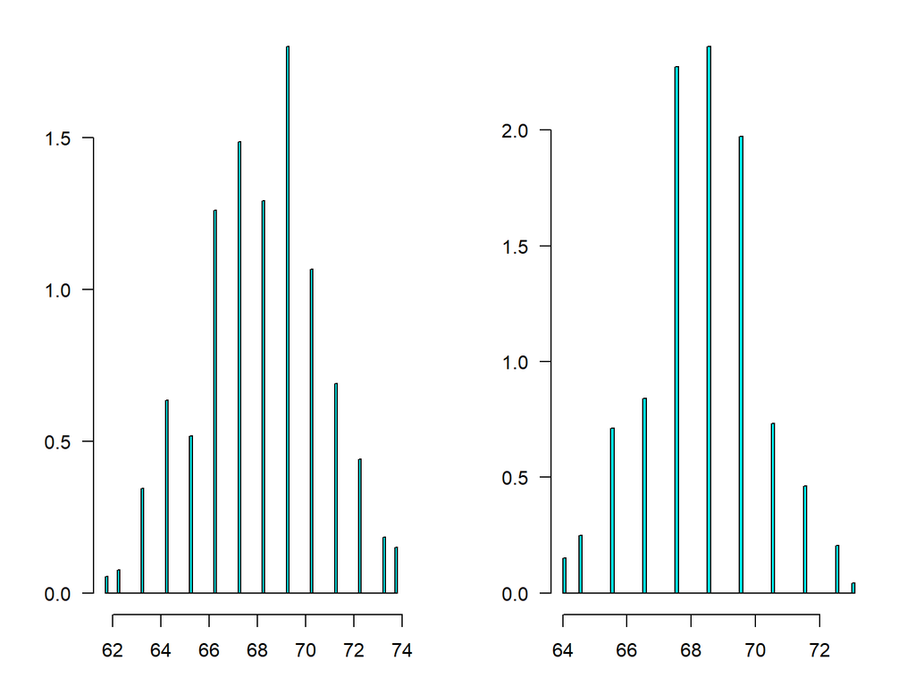

Pentru aceste histograme s-a utilizat un **binwidth** de 0.1 pentru a demonstra cât de puține valori pentru înălțimi apar în interval. Se poate observa că există multe goluri, iar înălțimile părinților se termină în .5, în timp ce înălțimile copiilor se termină în .2

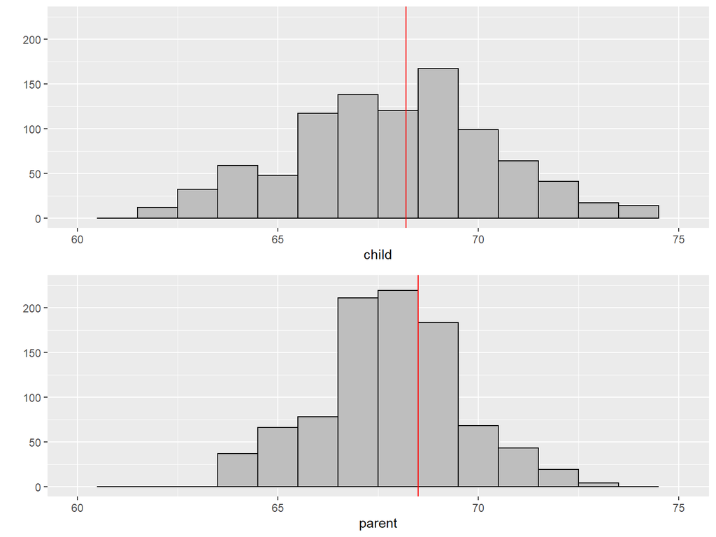

Histogramele de mai sus folosesc aceeași scalare și același **binwidth**, limitele axei orizonatele sunt alese să acopere toate înălțimile, iar limitele axei verticale sunt alese după modelele anterioare. Medianele sunt marcate cu o linie roșie verticală. Înălțimile părinților sunt mai concentrate, deci mediana e mai mare.

# 1.3 Exemple

*1.3.2 Înălțimi tați și fii*

Pentru exemplele următoare este folosit setul de date *father.son* din pachetul *UsingR*, care conține 1078 perechi de tipul *înălțime tată*-*înalțime fiu*.

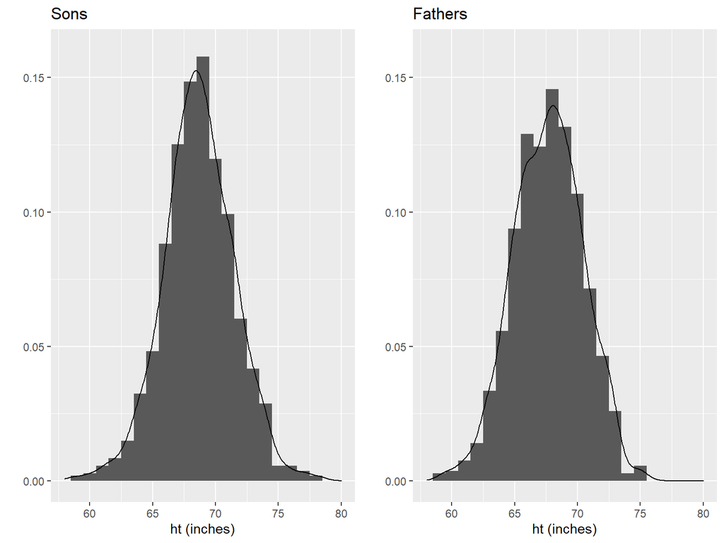

Distribuțiile înălțimii tatălui și fiului pot fi afișate ca histograme cu estimări de densitate suprapuse. Ambele distribuții par normale, deși la prima vedere am putea spune că înălțimile fiilor arată mai normal decât cele ale taților.

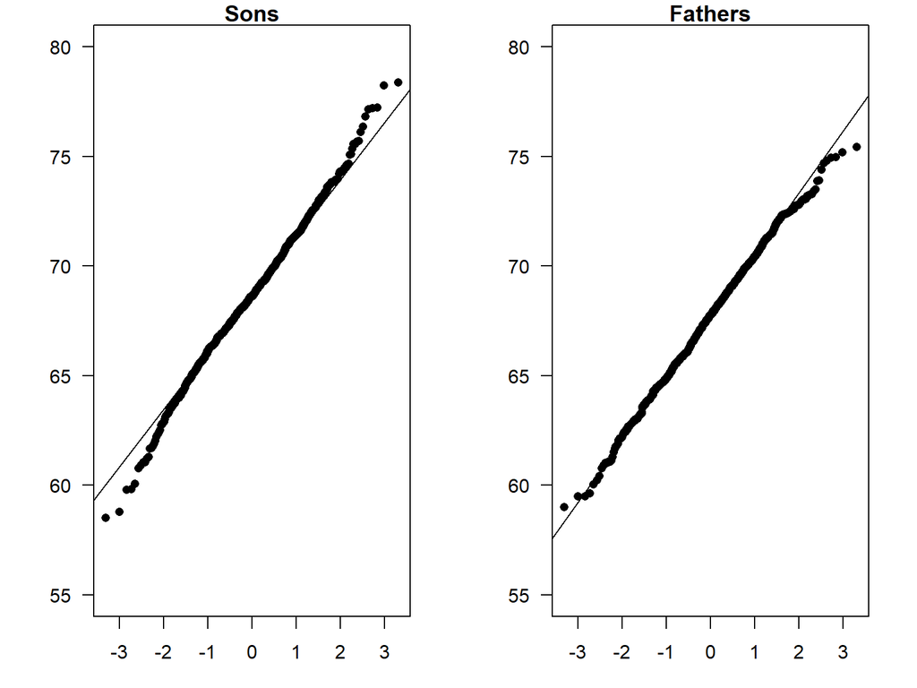

Un **Q-Q plot** ne ajută să comparăm densitatea unor variabile cu o densitate normală. Folosim *Q-Q plot* pentru înălțimile taților și fiilor și observăm că distribuția înălțimilor taților pare mai normală decât cea a fiilor, din cauza deviațiilor din cozile superioare și inferioare pentru fii.

Observăm că din cauză că setul de date a fost alterat: pentru galton au fost folosite valori rotunjite, iar pentru father.son au fost folosite prea multe zecimale, graficele pot fi interpretate diferit pentru aceleași variabile. Este întotdeauna mai bine să folosești datele nealterate.

# 1.3 Exemple

*1.3.3 Curse pe deal în Scoția*

Setul de date *hills* din pachetul *MASS* conține **timpi record**, **distanța parcursă** și **înălțimea** atinsă pentru 35 de curse pe dealuri din Scoția din 1984.

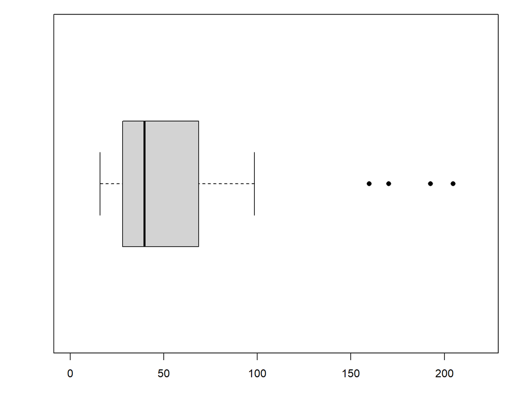

Figura de mai sus reprezintă un **boxplot** al *timpilor record*. Observăm că există 4 valori aberante, ceea ce înseamnă că 4 dintre curse au necesitat mai mult timp și efort. De asemenea, după poziția medianei din cutie, distribuția este asimetrică, fiind înclinată spre dreapta.

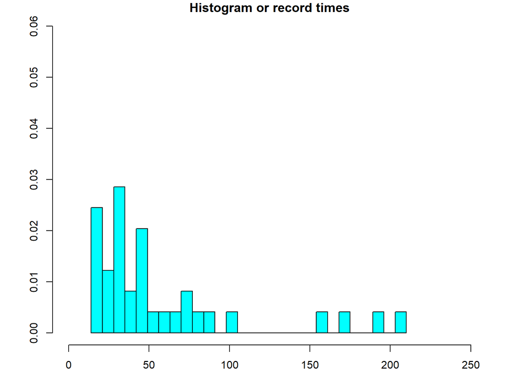

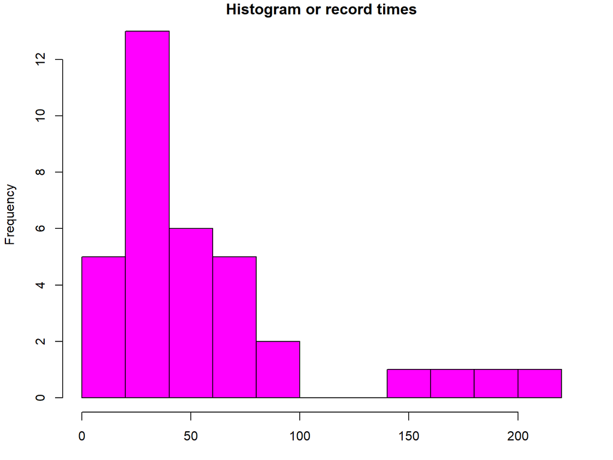

# 1.3 Exemple

*1.3.4 Locuințe in Boston*

Setul de date *Boston* din pachetul *MASS* conține date despre locuințele din Boston din anul 1978. Are 14 variabile pentru 506 de zone din Boston și din jurul lui. Principalul interes este reprezentat de *valorile mediane ale locuințelor ocupate pe zone*.

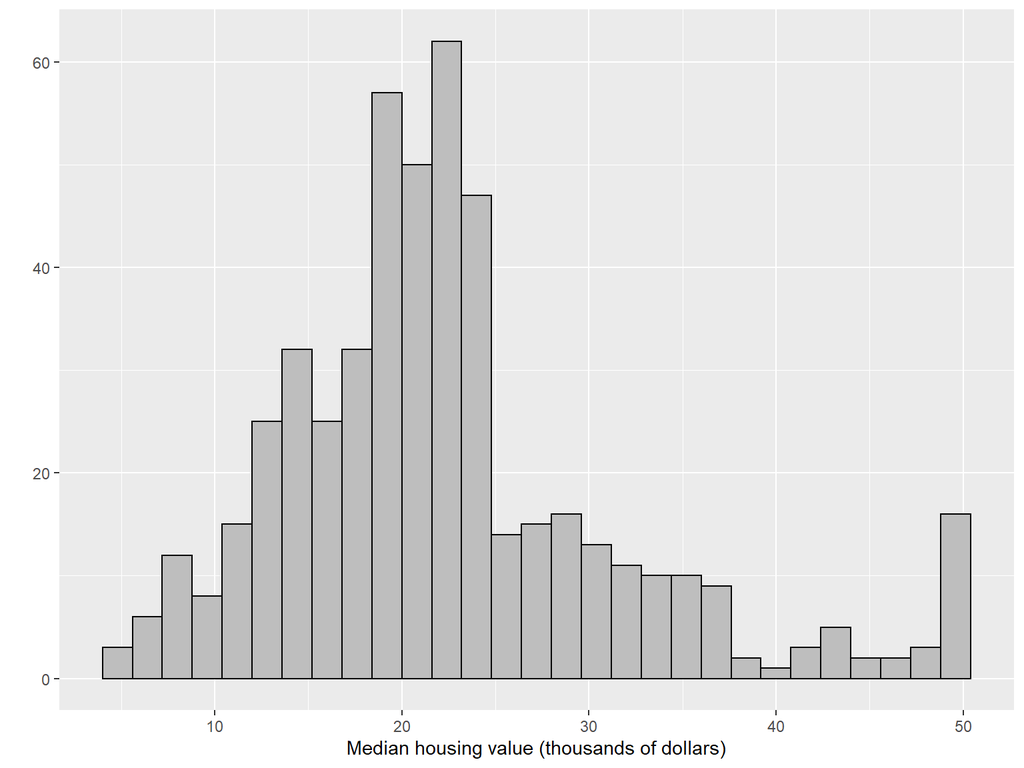

Frecvența înaltă a ultimului bin este neobișnuită ceea ce înseamnă că există multe zone cu prețul caselor de 50 de mii de dolari. În plus, pare să existe o scădere bruscă în mijloc.

*Pentru a investiga aceste aspecte, este de folos să examinăm datele direct, fie cu un tabel, fie cu o histogramă cu un binwidth foarte mic.*

```
##
##    5  5.6  6.3    7  7.2  7.4  7.5  8.1  8.3  8.4  8.5  8.7  8.8  9.5  9.6  9.7
##    2    1    1    2    3    1    1    1    2    2    2    1    2    1    1    1
## 10.2 10.4 10.5 10.8 10.9   11 11.3 11.5 11.7 11.8 11.9   12 12.1 12.3 12.5 12.6
##    3    2    2    1    2    1    1    1    2    2    2    1    1    1    1    1
## 12.7 12.8   13 13.1 13.2 13.3 13.4 13.5 13.6 13.8 13.9   14 14.1 14.2 14.3 14.4
##    3    1    1    4    1    3    4    2    2    5    2    1    3    1    2    2
## 14.5 14.6 14.8 14.9   15 15.1 15.2 15.3 15.4 15.6 15.7   16 16.1 16.2 16.3 16.4
##    3    2    1    3    3    1    3    1    2    5    1    1    3    2    1    1
## 16.5 16.6 16.7 16.8   17 17.1 17.2 17.3 17.4 17.5 17.6 17.7 17.8 17.9   18 18.1
##    2    2    2    2    1    3    3    1    3    3    1    1    5    1    1    1
## 18.2 18.3 18.4 18.5 18.6 18.7 18.8 18.9   19 19.1 19.2 19.3 19.4 19.5 19.6 19.7
##    3    2    3    4    2    3    2    4    2    4    2    5    6    4    5    2
## 19.8 19.9   20 20.1 20.2 20.3 20.4 20.5 20.6 20.7 20.8 20.9   21 21.1 21.2 21.4
##    3    4    5    5    2    4    4    3    6    2    3    2    3    2    5    5
## 21.5 21.6 21.7 21.8 21.9   22 22.1 22.2 22.3 22.4 22.5 22.6 22.7 22.8 22.9   23
##    2    2    7    2    3    7    1    5    2    2    3    5    2    4    4    4
## 23.1 23.2 23.3 23.4 23.5 23.6 23.7 23.8 23.9   24 24.1 24.2 24.3 24.4 24.5 24.6
##    7    4    4    2    1    2    4    4    5    2    3    1    3    4    3    2
## 24.7 24.8   25 25.1 25.2 25.3 26.2 26.4 26.5 26.6 26.7   27 27.1 27.5 27.9   28
##    3    4    8    1    1    1    1    2    1    3    1    1    2    4    2    1
## 28.1 28.2 28.4 28.5 28.6 28.7   29 29.1 29.4 29.6 29.8 29.9 30.1 30.3 30.5 30.7
##    1    1    2    1    1    3    2    2    1    2    2    1    3    1    1    1
## 30.8   31 31.1 31.2 31.5 31.6 31.7   32 32.2 32.4 32.5 32.7 32.9   33 33.1 33.2
##    1    1    1    1    2    2    1    2    1    1    1    1    1    1    2    2
## 33.3 33.4 33.8 34.6 34.7 34.9 35.1 35.2 35.4   36 36.1 36.2 36.4 36.5   37 37.2
##    1    2    1    1    1    3    1    1    2    1    1    2    1    1    1    1
## 37.3 37.6 37.9 38.7 39.8 41.3 41.7 42.3 42.8 43.1 43.5 43.8   44 44.8 45.4   46
##    1    1    1    1    1    1    1    1    1    1    1    1    1    1    1    1
## 46.7 48.3 48.5 48.8   50
##    1    1    1    1   16
```

Un **tabel** nu ne prea ajută în acest caz,dar ne oferă informația că datele sunt raportate la o zecimală (în mii de dolari).

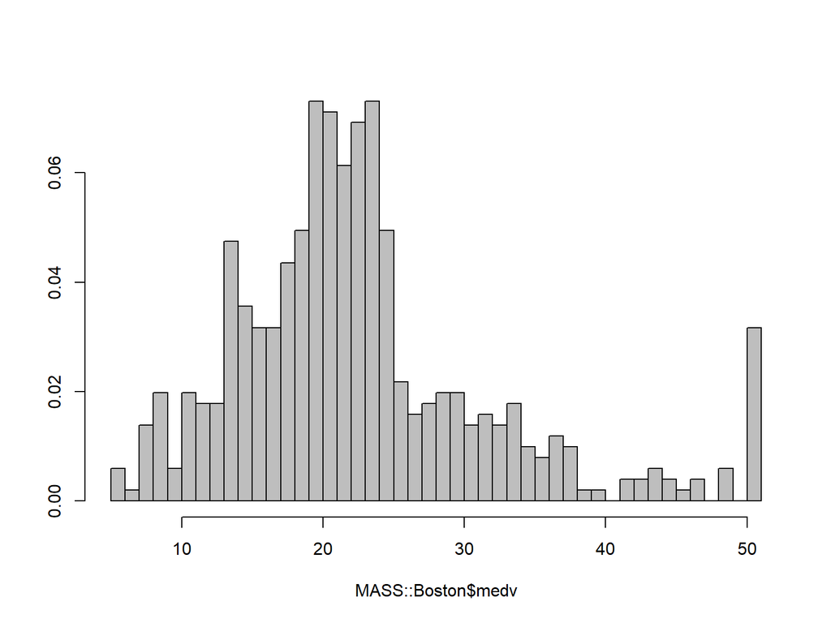

O **histogramă** cu binwidth=1 confirmă că există multe valori în ultimul bin (la 50), dar nu ne oferă informații despre scăderea de la 25.

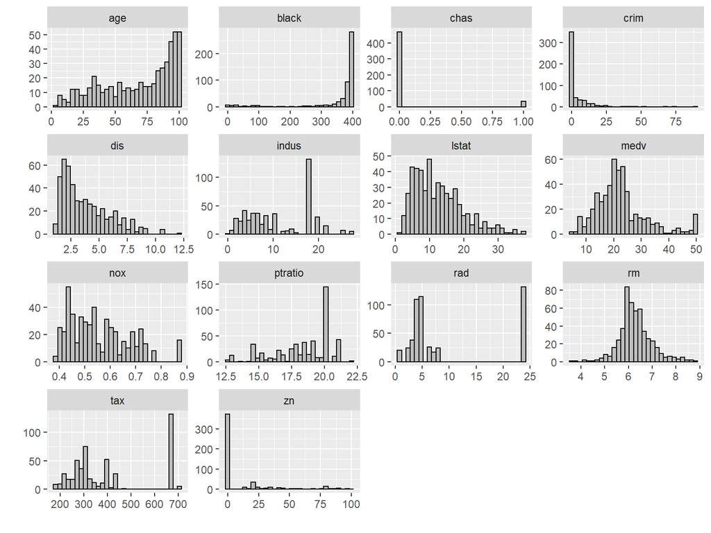

O histogramă a celor 14 variabile din setul de date Boston (cu default bins=30). Se observă o gamă largă de forme ale histogramelor, fiecare putând fi interpretată diferit. Scări diferite ale graficelor ar putea dezvălui mai multe informații și ar putea fi interpretate mai ușor.

# 1.3 Exemple

*1.3.5 Cât durează un film?*

Setul de date *movies* din pachetul *ggplot2* conține 24 de variabile și 58 788 de cazuri, fiind unul din seturile de date foarte mari. Una dintre variabile este **durata** unui film în minute, la care ne vom uita în continuare.

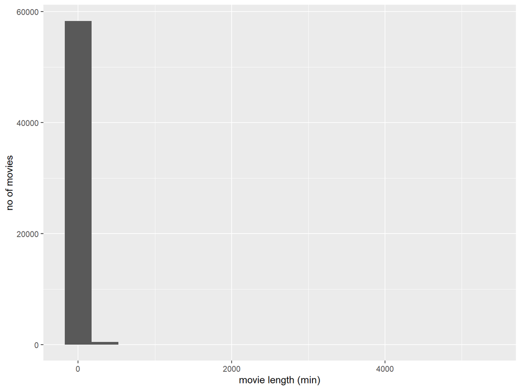

Histograma *duratei* filmelor care arată că trebuie să existe cel puțin *o valoare aberantă* extremă în dreapta, distorsionând scara. În acest caz, histograma nu oferă prea multe informații despre outliers, însă semnalizează prezența acestora. Cu peste 58 000 de cazuri în binul cel mai din stânga, un singur caz nu va fi niciodată vizibil, o problemă tipică pentru seturile mari de date.

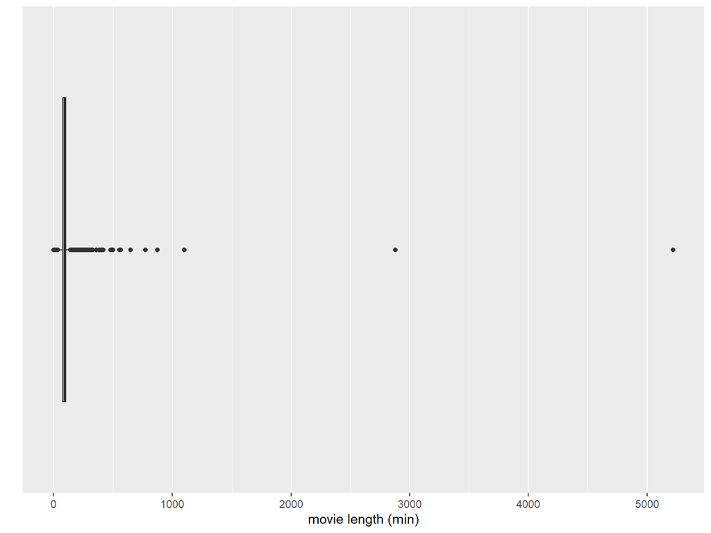

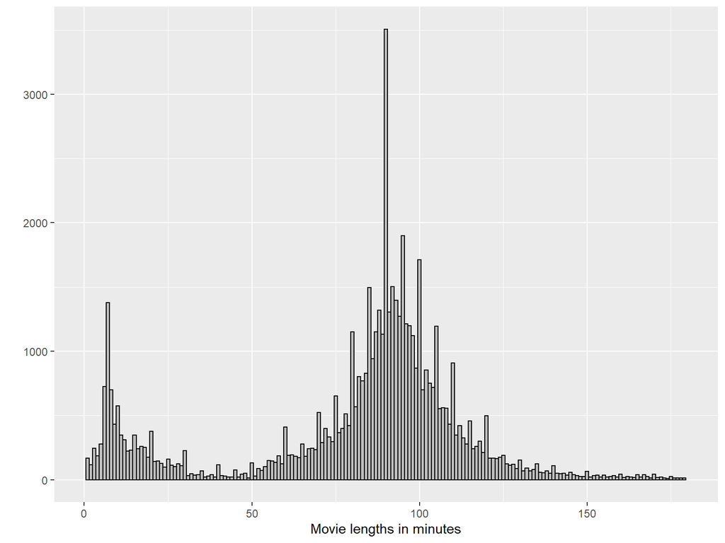

În figura de mai sus este prezentată o histogramă folosind lățimea binului de 1 minut. Putem observa mai multe aspecte legate de durata filmelor:

- sunt puține filme cu durata mare (care depășesc două ore și jumătate)
- cea mai frecventă durată a filmelor scurte este de 7 minute
- cea mai frecventă durată a filmelor lungi este de 90 de minute
- este foarte clar că sunt preferate durate rotunjite: 90, 80, 85, 95, 100

# 2.1 Scatterplots

Pentru a evidenția asocierile dintre variabile, cel mai adesea se utilizează un **scatterplot** (diagramă de dispersie). Scatterplot-urile ajută și la identificarea valorilor aberante și la observarea proprietăților distribuțiilor.

**Ce proprietăți sunt vizibile cu ajutorul unui scatterplot?**

- **RELAȚII CAUZALE(liniare și neliniare)** - o variabilă poate influența o alta într-un anumit fel (exemplu: oamenii cu mai multă experiență sunt plătiți mai mult); de obicei, variabila dependentă este plasată pe axa verticală
- **ASOCIERI** - variabilele pot fi asociate între ele fără a fi direct legate cauzal (exemplu: copiii obțin note mari la engleză și la matematică, deoarece sunt inteligenți, nu pentru că abilitatea într-un subiect este motivul pentru abilitatea în celălalt)
- **VALORI ABERANTE(outliers) sau GRUPURI DE VALORI ABERANTE** - cazurile pot fi valori aberante în 2 dimensiuni fără să fie valori aberante în fiecare dimensiune separat (exemplu: oamenii mai înalți sunt în general mai grei, dar pot exista oameni de înălțime medie care sunt mai grei sau mai ușori pentru înălțimea lor, astfel că se evidențiază în rândul populației)
- **CLUSTERE** - uneori există grupuri de cazuri care sunt separate de restul datelor
- **GOLURI(gaps)** - ocazional, anumite combinații de valori nu apar (exemplu: filme care sunt evaluate foarte bine sunt apreciate mai des, dar filme pe care puțini le plac sunt rareori evaluate)
- **BARIERE** - unele combinații de valori nu pot fi posibile (exemplu: nimeni nu poate avea mai mulți ani de experiență decât vârsta)
- **RELAȚIE CONDIȚIONALĂ** - uneori, relația dintre două variabile este mai bine explicată printr-o descriere condițională, decât printr-o funcție (exemplu: un plot al venitului în funcție de vârstă este probabil să difere înainte și după vârsta de pensionare)

# 2.2 Modelarea și testarea relațiilor dintre variabile

**1. CORELAȚIA**

- Dacă calculăm un coeficient de corelație, este util să desenăm un scatterplot pentru a afla ce ar putea însemna coeficientul.
- Coeficienții de corelație măsoară asocierea liniară
- Dacă desenăm un scatterplot și observăm o asociere liniară, este o idee bună să calculăm coeficientul de corelație pentru a măsura exact ce nivel de corelație avem

**2. REGRESIA**

- Având în vedere o relație cauzală între 2 variabile vizibilă pe un scatterplot, regresia poate fi utilizată pentru a potrivi un model
- Poate fi util să suprapunem modelul pe un scatterplot, să adăugăm ‘benzi de încredere’ pentru potrivire sau intervale preditictive pentru posibile puncte noi

**3. NETEZIRE (SMOOTHING)**

- Dacă nu este propus niciun model analitic pentru Y în funcție de X, atunci poate fi încercat un ‘netezitor neliniar’
- **loess** (regresia ponderată locală) este o abordare interesantă și este utilizată în unele situații în R ca implicit, de exemplu în diagrame ale obiectelor model
- Recent, **funcțiile spline** au fost folosite mai mult, parțial pentru că au proprietăți statistice mai bune și pentru că este mai ușor să desenezi ‘benzi de încredere’ pentru ele

**4. ESTIMAREA DENSITĂȚII BIVARIATE**

- Se pot folosi kde2d din MASS, kde din ks sau bkde2d din KernSmooth

**5. VALORI ABERANTE**

- Punctele care sunt valori aberante în diagramele de dispersie pot fi valori aberante pe una dintre cele două dimensiuni individual sau pur bivariate
- Este dificil să decizi dacă un punct este o valoare aberantă bivariată sau dacă mai multe puncte dintr-un grup sunt valori aberante
- Estimatorii de densitate sunt o abordare, dar pot fi problematici fie din cauza mascării, fie a “swamping”

# 2.3 Exemple

*2.3.1 Atleți la Jocurile Olimpice din 2012 de la Londra*

Setul de date *oly12* din pachetul *VGAMdata* conține date despre 10 384 de atleți participanți la Jocurile Olimpice din 2012 de la Londra, printre care **înălțimea** și **greutatea.** Printr-un scatterplot s-a observat relația dintre înălțime și greutate. Dintre cei 10 384 de atleți, 1346 nu sunt afișați din cauză că una din măsurătorile necesare lipsește. Relația așteptată dintre greutate și înălțime poate fi văzută clar, deși este puțin ascunsă de niște valori aberante care distorsionează scara. Dat fiind numărul mare de puncte, există multă supraplotare, iar majoritatea punctelor din mijloc reprezintă mai mult decât un caz (sunt 57 de atleți care au 1.7m și 60 kg). Această problemă poate fi rezolvată utilizând alpha-blending, dând fiecărui punct o pondere egală cu parametrul alpha din geom_point, deși așa punctele aberante sunt mai greu de văzut.

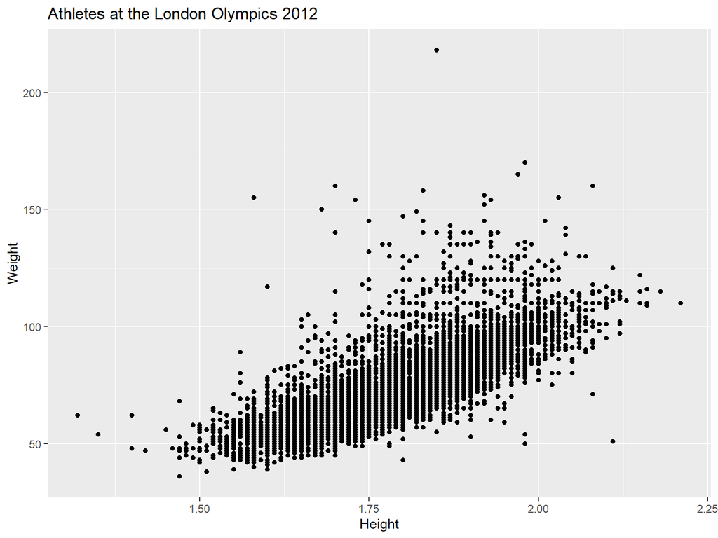

Scatterplot al greutății în funcție de înălțime pentru sportivii de la Jocurile Olimpice de la Londra 2012. Se observă faptul că greutatea crește odată cu înălțimea. Sunt câteva valori aberante care afectează scările.

# 2.3 Exemple

*2.3.2 The evils of drink?*

Setul de date *DrinksWages* din pachetul *HistData* conține date despre 70 de observații asupra a 6 variabile, oferind numărul de nebăutori (sober) și de băutori (drinks) aparținând mai multor categorii ocupaționale (trade). Karl Pearson a investigat influența băuturii asupra diferitelor aspecte ale vieții de familie la începutul secolului al XX-lea.

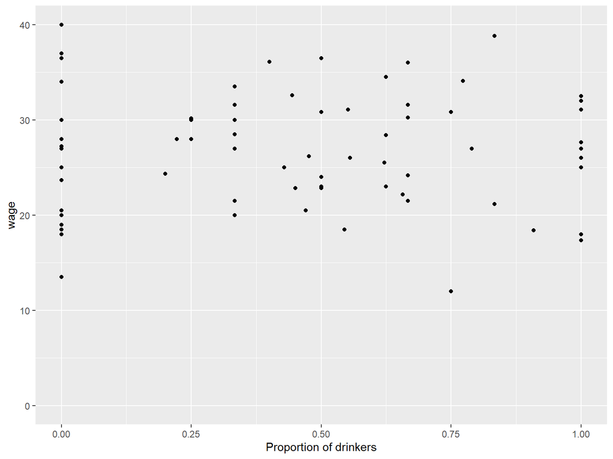

Scatterplot al **salariului** (salariu mediu săptămănal în shillings) în funcție de **băutori/n** (raportul băutorilor; n=nr total de lucrători pentru o meserie) pentru 70 de meserii diferite. Nu pare să existe vreo relație între aceste 2 variabile. Există un număr surprinzător de meserii în care fie toți lucrătorii sunt băutori, fie niciunul.

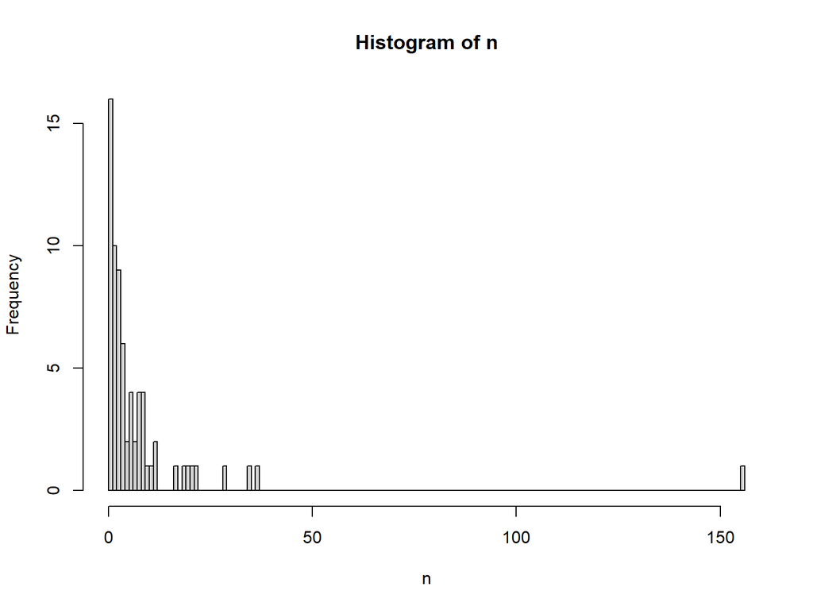

O privire asupra distribuției numerelor din studiu în funcție de meserie care explică faptul că unele meserii au băutori 100% și altele nu au deloc.

# 2.3 Exemple

*2.3.3 Gheizerul Olf Faithful*

Setul de date *geyser* din pachetul *MASS* conține 299 de observații asupra **duratei erupțiilor** și asupra **timpului până la următoarea erupție**.

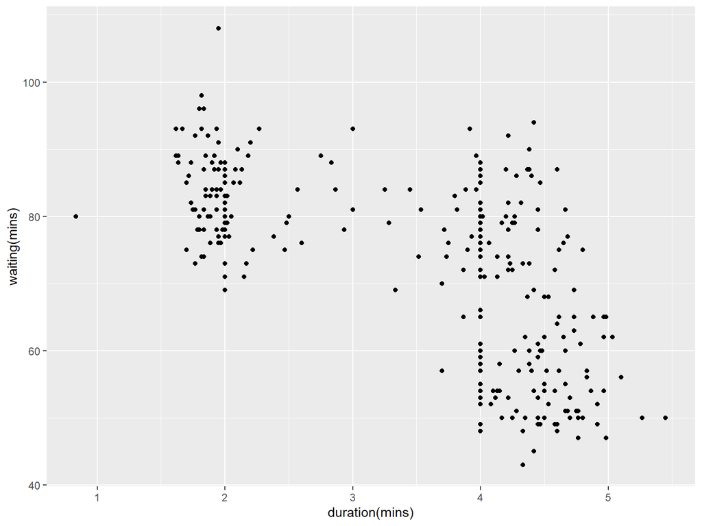

Printr-un scatterplot al **timpului de aștepare** până la următoarea erupție față de **durata de erupție**, se observă faptul că după o erupție de scurtă durată, trebuie să aștepți mai mult timp pentru următoarea.

O durată scurtă implică un timp lung de așteptare, în timp ce o durată lungă implică un timp lung sau scurt de așteptare. Pot fi diferențiate 3 clustere și câteva valori aberante, dar există și o sugestie de valori rotunjite pentru duratele erupțiilor (numărul de durate de 2 și 4 minute). Pentru a evalua clusterele, luăm în considerare o estimare a densității. Figura de mai jos afișează contururile unei estimări de desnitate bivariată care susține ideea că există 3 clustere.

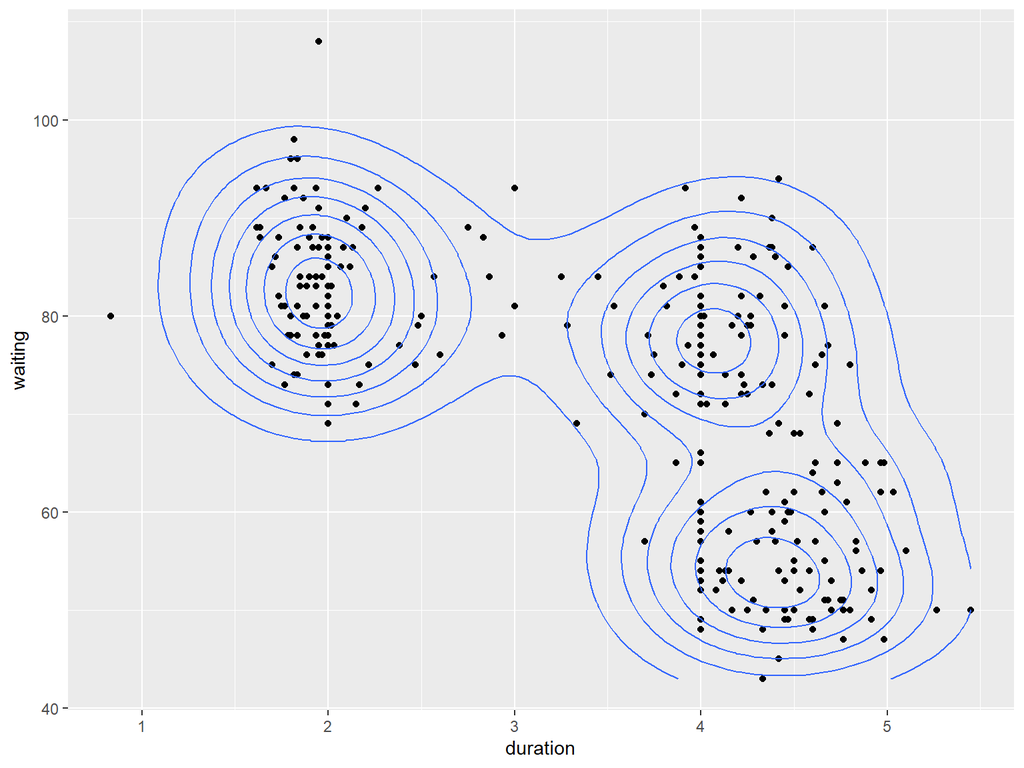

Același grafic de dispersie cu contururi de estimare a densității bivariate. Există dovezi a 3 concentrări de date, a 2 valori aberante univariate (o erupție cu durată redusă și una cu un timp mare de așteptare) și a unei valori aberante bivariate.

# 2.3 Exemple

*2.1.4 Rating-uri de filme*

Ne vom uita la variabilele *rating* (rating mediu al utilizatorilor IMDb) și *voturi* (numărul de persoane care au evaluat un film) din setul de date *movies* din pachetul *ggplot2*.

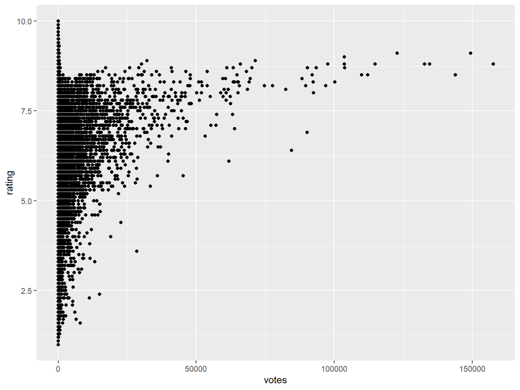

Un scatterplot al rating-urilor medii ale filmelor în funcție de numărul de persoane care au votat. Filmele evaluate foarte des au o medie a rating-urilor mai mare, dar cele mai mari rating-uri sunt obținute de filmele care sunt evaluate mult mai rar.

Graficul de dispersie are aproape forma literei mici “r”. Există multe informații care reies din acest plot:

- Nu există filme cu *multe voturi* și cu un *rating mediu scăzut*.
- Pentru filmele cu *mai mult de un număr mic de voturi*, rating-ul mediu *crește* cu numărul de voturi.
- Niciun film cu *multe voturi* nu are un rating mediu apropiat de *maximul posibil*. Pare să existe o barieră care nu poate fi trecută.
- Puține filme cu un *număr mare de voturi*, peste 50 000, arată ca valori aberante. Ele au un *rating net mai scăzut* decât alte filme cu un număr similar de voturi.
- Filmele cu un *număr redus de voturi* pot avea *orice* rating mediu de la cel mai mic la cel mai mare.
- Singurele filme cu un *rating mediu ridicat* sunt filmele cu relativ *puține voturi*.

# 2.4 Adăugare de modele: linii și smooths

Oamenii sunt buni la descoperirarea tiparelor care nu există cu adevărat și, de asemenea, sunt buni la omiterea unor tipare care chiar există. Dacă credeți că există o relație cauzală liniară între 2 variabile dintr-un scatterplot, este logic să potrivim un model pe care să îl adăugăm în grafic.

**Exemple**

*2.4.1 Mașini și mpg*

Setul de date *Cars93* din pachetul *MASS* conține 27 de informații pentru 93 de mașini. Datele au fost colectate în urmă cu aproximativ 20 de ani. Trasarea *MPG.city* (MPG=mile per galon US după evaluarea EPA) în raport cu *greutatea* arată clar o relație neliniară, pe măsură ce economia de combustibil scade cu greutatea destul de repede inițial și apoi mai lent.

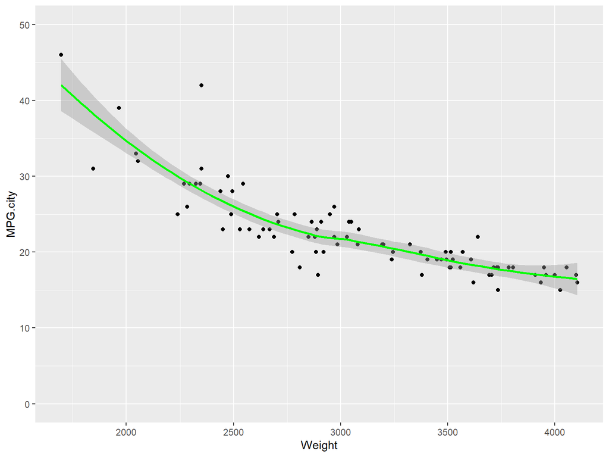

Un scatterplot al *MPG.city* raportat la *greutate*. O linie **smooth** a fost suprapusă *(estimarea unei tendințe, de obicei prin intermediul mediilor ponderate ale observațiilor)*. Mașinile mai grele fac progresiv mai puține mile la galon. Mașina care cântărește 2350 de pounds cu un mpg relativ înalt a fost Honda Civic. Axa y a fost desenată de la 0 pentru a sublinia limita inferioară a valorii mpg.

*2.4.2 Înălțimile persoanelor*

Este utilizat setul de date *father.son* din pachetul *UsingR*, care conține 1078 perechi de tipul *înălțime tată*-*înalțime fiu*. S-a adăugat pe un scatterplot cea mai bună potrivire liniară, împreună cu un interval punctual de încredere de 95%. Diagonala y=x a fost desenată în scopuri comparative.

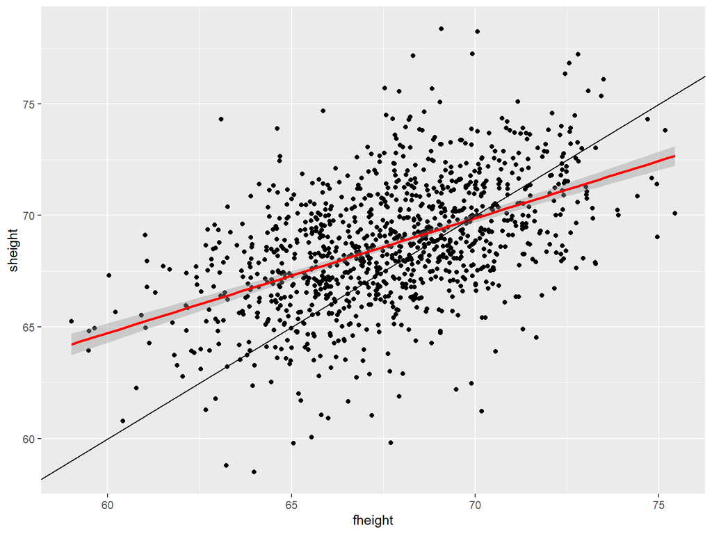

Un scatterplot al *înălțimilor fiilor* relativ la *înălțimile taților*. Cea mai potrivită linie de regresie are panta puțin peste 0.5, după cum se poate observa în comparație cu dreapta y=x. Înălțimea unui fiu este influențată de înălțimea tatălui, dar există multă variabilitate inexplicabilă.

Această figură ilustrează regresia la medie. Tații înalți au fii care sunt înalți, dar, în medie, nu la fel de înalți ca tații. Tații scunzi au fii scunzi, dar, în medie, nu la fel de scunzi ca tații.

Pentru a explora dacă un model neliniar ar putea fi garantat, am putea potrivi un model mai smooth sau un plot cu o linie smooth împreună cea mai bună linie de regresie. Pentru aceste date, un model liniar este potrivit, deoarece cele două curbe sunt practic identice.

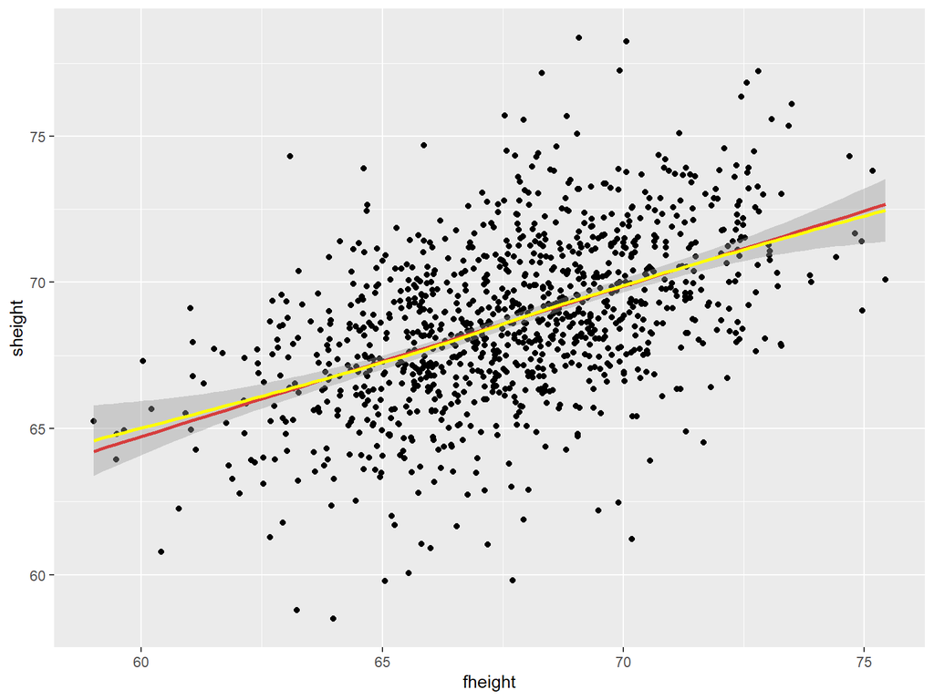

Scatterplot al înălțimilor fiilor relative la înălțimie taților cu o linie de regresie liniară și o linie smooth suprapusă.

Adăugarea unei **linii** sau a unei **linii netede(smooth)** (sau ambele) face modelarea explicită. Când te uiți la un grafic, folosești modele implicite în a judeca ce vezi și este bine să le formalizezi unde este posibil. Cu înălțimile fiilor și ale taților, te-ai aștepta la un fel de asociere pozitivă și ai interpeta graficul cu acea imagine îm minte.

În alte situații, de exemplu când același plot include atât femei, cât și bărbați, te-ai aștepta să vezi semne că există două grupuri. Odată ce vedeți un grafic, datele în sine influențează caracteristicile pe care le studiați și modul în care le interpretăm.

*Impresiile subiective pot oferi informații valoroase, dar trebuie confirmate prin verificarea cu alte vizualizări ale datelor și prin testare obiectivă, unde este cazul.*

# 2.5 Compararea grupurilor din scatterplot

Setul de date despre sportivii olimpici a suferit de supraplotare, ceea ce este un motiv bun pentru ajustarea graficului. Pot fi utilizate estimări de densitate suprapuse sau alpha-blending, însă având în vedere structura datelor, anume că ne așteptăm ca înălțimea și greutatea să difere în funcție de sexul sportivilor și sportul lor, o abordare mai bună ar fi să împărțim datele după posibile variabile explicative.

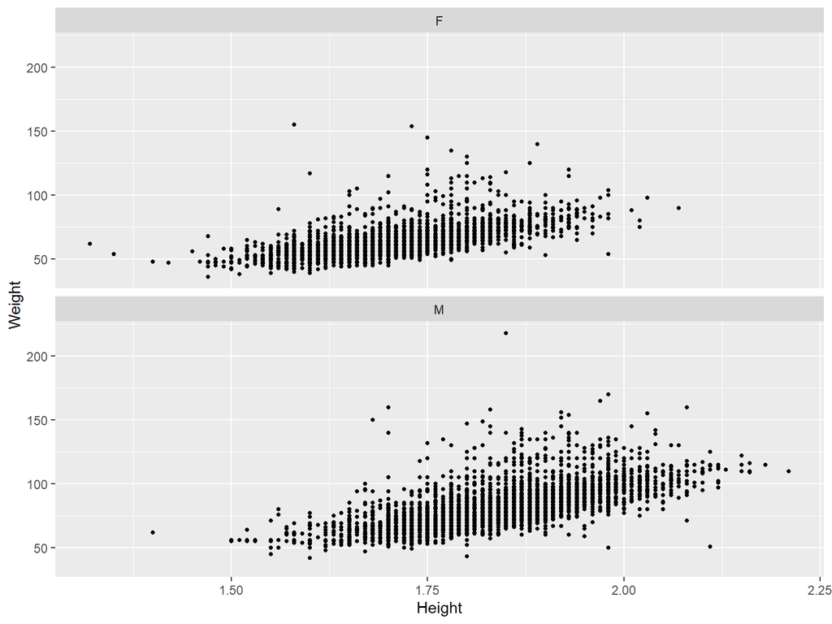

Scatterplot diferențiat pentru femei și bărbați.

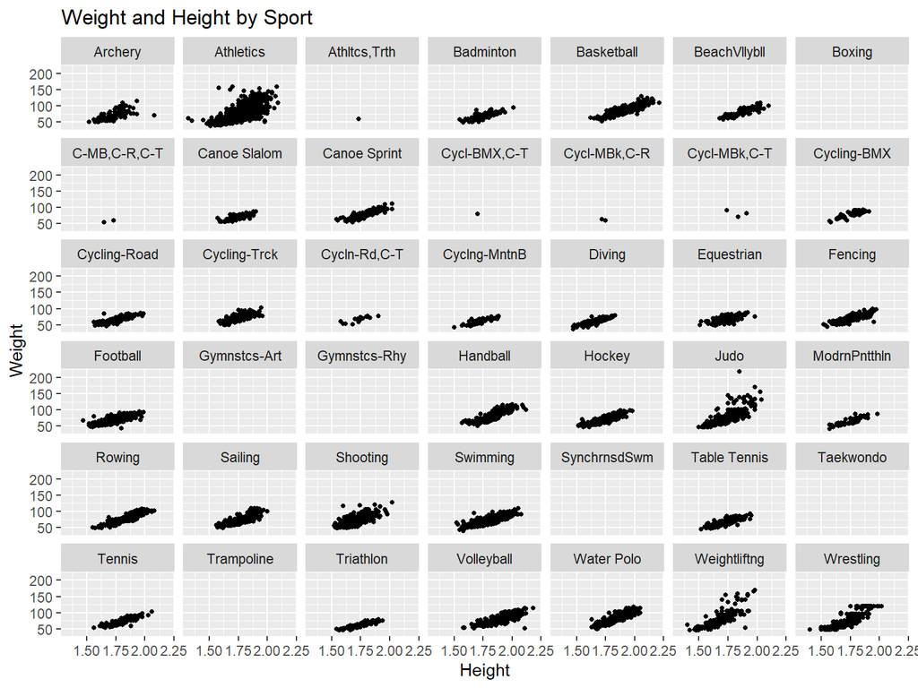

Scatterplots pentru greutate și înălțime pentru diferitele sporturi de la Jocurile Olimpice de la Londra. Lipsesc date pentru anumite sporturi. Asocierea dintre greutate și înălțime pare lineară pentru majoritatea sporturilor.

# 2.6 Matrice ale scatterplot-urilor (sploms)

Sunt tabele de scatterplot-uri ăn care fiecare variabilă este plotată în funcție de celelalte. Sunt bune pentru seturile de date ce conțin un număr mic de variabile.

**Exemple**

**2.4.1 Crime în SUA**

Setul de date *crime. us* din pachetul *VGAMdata* include cifre absolute ale criminalității și ratele criminalității în funcție de populație pentru cele 50 de state din SUA în 2009.

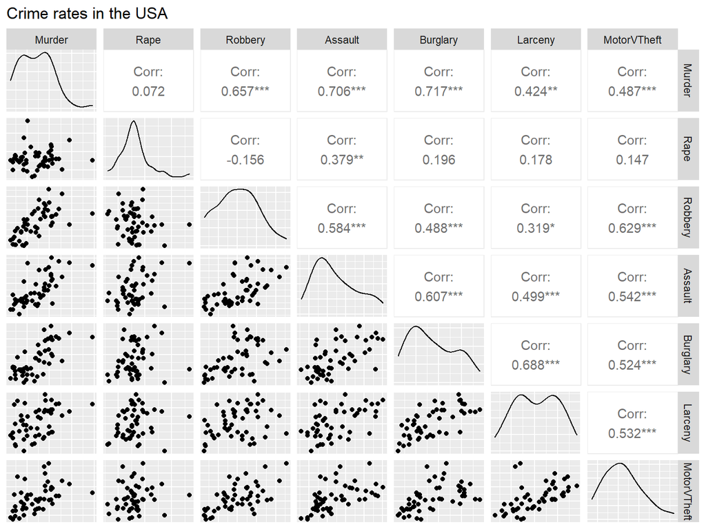

**Splom** al ratelor celor 7 tipuri de infracțiuni. Arată, de asemenea, estimarea densității pentru variabile pe diagonală. În plus, este trecut și *coeficientul de corelație* dintre variabile.

Nivelurile ratelor sunt destul de diferite pentru crime diferite. Ratele uciderilor de stat din acest set de date ajung la aproape 12 la 100 000 de locuitori, în timp ce ratele de furt ajung la peste 2700 la 100 000 de locuitori.

Ratele pentru majoritatea infracțiunilor par asociate pozitiv, unele mai puternic decât altele (de exemplu, crima și jaful). Rata violului nu este asociată foarte mult cu niciuna dintre celelalte rate de criminalitate violentă. Sunt câteva valori aberante, precum cele 2 state cu rate ridicate de furt de autovehicule în scatterplot-ul cu furtul(larceny) (California și Nevada).

Setul de date are numai 50 de cazuri, deci nu putem interpreta prea mult forma graficelor sau coeficienții de corelație. De asemenea, trebuie luate în considerare dimensiunile diferite ale populației statelor. Alaska, Dakota de Nord, Wyoming și Vermont sunt considerate fiecare ca având o pondere egală cu California, chiar dacă populațiile lor sunt mai mici de 2% din populația Californiei.

**2.4.2 Bancnote elvețiene**

Setul de date *bank* din pachetul *gclus* include 6 măsurători pentru fiecare din cele 100 de bancnote elvețiene autentice și 100 de bancnote falsificate.

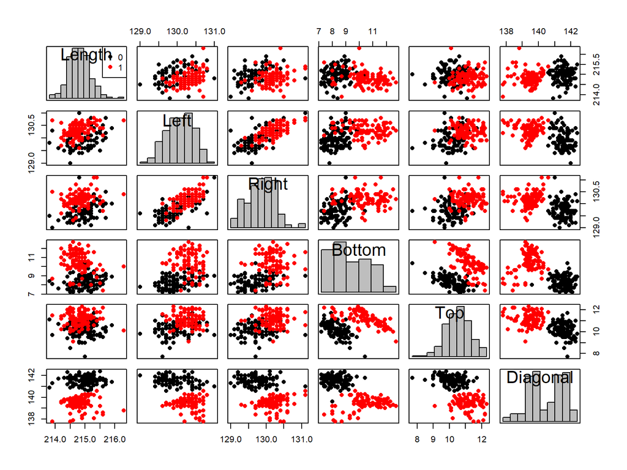

# *3.1 Diagramă de coordonate paralele (pcp)*

- Pentru a reprezenta relațiile dintre mai multe variabile se utilizează, cel mai adesea, o **diagramă de coordonate paralele(pcp)**
- Într-un *scatterplot*, axele Ox și Oy sunt perpendiculare una pe cealaltă, în timp ce într-o *diagramă de coordonate paralele* toate axele sun paralele între ele
- Fiecare variabilă are propria sa **axă verticală individuală** (sau toate axele sunt orizontale), iar axa este de obicei scalată de la valorile minime la cele maxime ale variabilelor, astfel încât este utilizat intervalul complet al fiecărei axe
- Valorile fiecărui caz pe axele adiacente sunt unite prin linii, astfel încât o linie poligonală peste toate axele definește un caz

**Proprietăți ce se pot evidenția printr-un pcp**

- Având identificate valorile aberante, corelațiile sau clusterele cu abordări analitice, diagramele de coordonate paralele sunt foarte utile pentru verificarea rezultatelor
- Oferă o privire în ansamblu asupra distribuțiilor univariate pentru mai multe variabile simultan: dacă acestea sunt înclinate, dacă există valori aberante, dacă există goluri sau concentrații de date

**Exemple**

*1 Setul de date food*

Setul de date *food* din pachetul *MMST* conține 961 de cazuri pentru 7 variabile. Variabilele par înclinate la dreapta, deoarece sunt mai multe linii în partea de jos a graficlui decât în partea de sus. Un caz este o valoare extremă pentru câteva din variabile (linia începând de sus, stânga). Pare să existe un subgrup mic cu valori înalte similare (grupul de linii apropiate între primele 5 variabile)

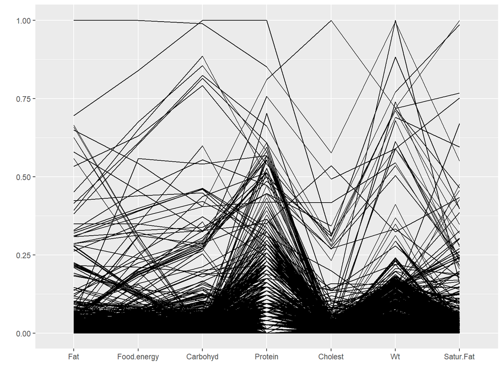

Împărțind fiecare valoare din setul de date food la greutate (Wt), observăm că pcp-ul se modifică astfel: există mai multe grupuri distincte cu valori ridicate ale variabilei - Fat, Carbohyd și câte o valoare aberantă pentru variabilele Protein și Cholest. De asemenea, putem spune că variabila Carbohyd nu mai este înclinată, cum era în exemplul anterior.

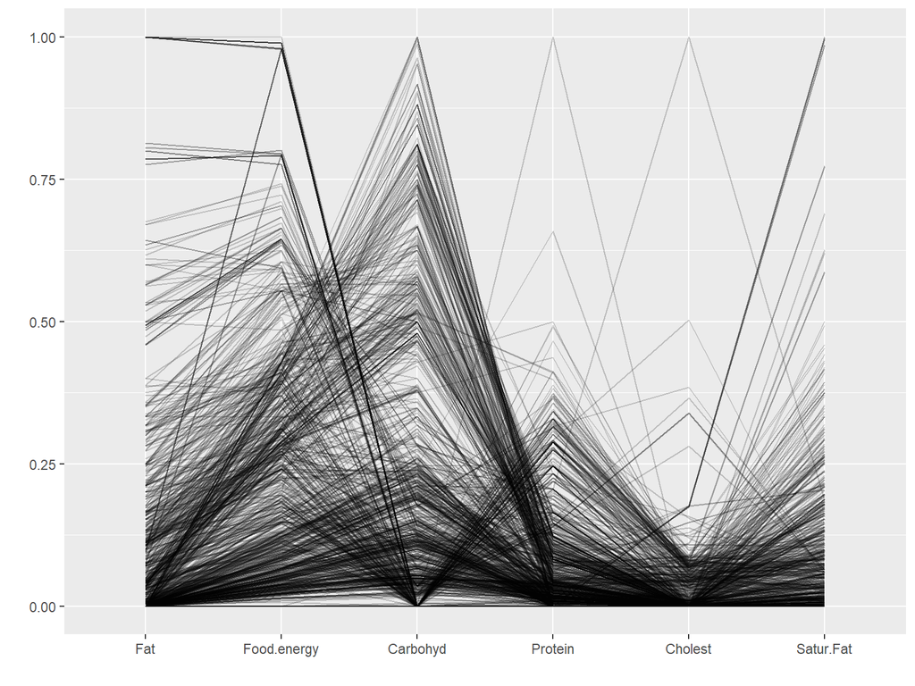

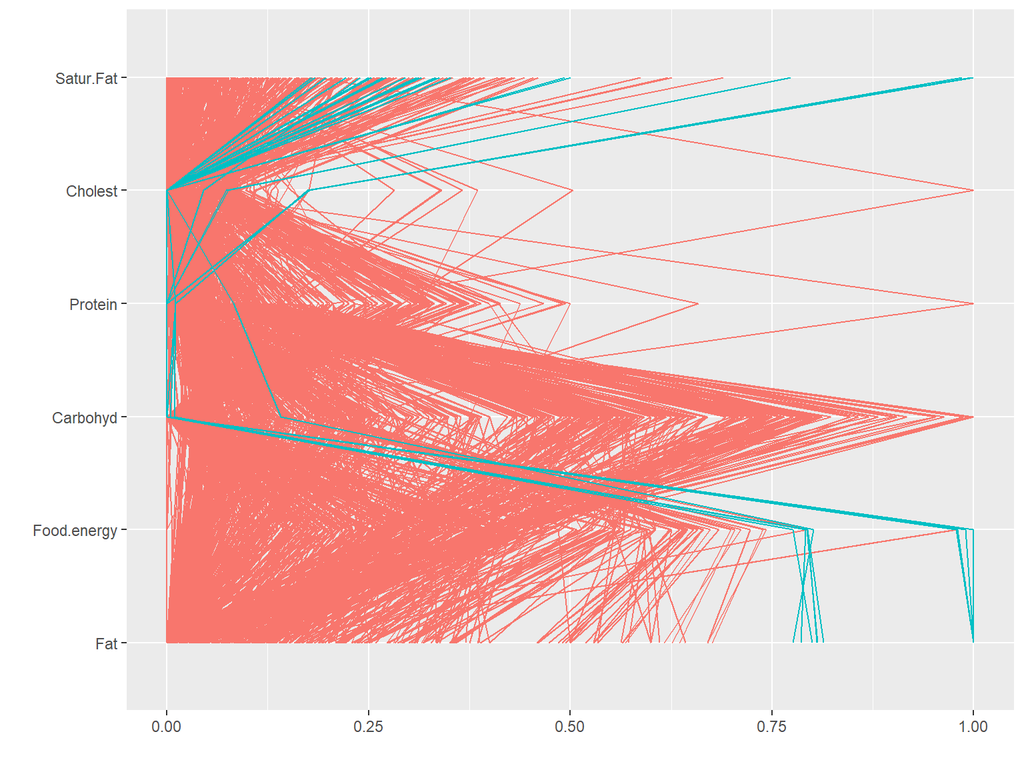

Folosim exemplul de mai sus pentru a evidenția câteva dintre proprietățile unui pcp, cum ar fi colorarea unui grup de interes și ordonarea variabilelor după un anumit criteriu. Astfel, variabilele din pachetul food au fost ordonate în funcție de o noua variabilă **fatX** care are valoarea 1 dacă food.Fat > 0.75 și 0 în rest. Se observă că liniile albastre reprezintă cazurile care au fatX = 1.

*2 Setul de date iris*

Setul de date **iris** din pachetul **datasets** conține 150 de înregistrări despre trei specii diferite de iriși: setosa, versicolor, virginica, fiecare înregistrare conținând măsurători în funcție de specie.

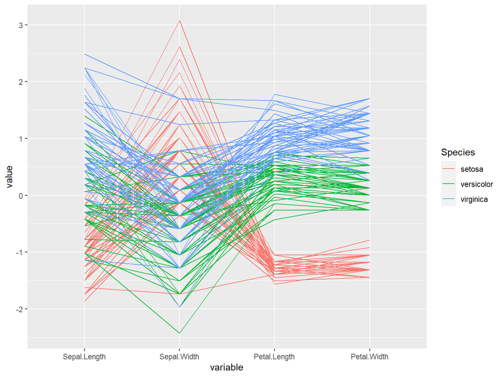

În pcp-ul ilustrat mai sus, se poate observa foarte clar că specia *setosa* este separată de celelalte două specii prin următoarele caracteristici: valorile lungimilor și lățimilor petalelor sunt mult mai mici, iar valorile lățimilor sepalelor sunt mult mai mari, aici existând chiar și o valoare aberantă pentru această specie. De asemenea, este foarte clară separarea speciilor *virginica* și *versicolor*, datorită măsurătorilor petalelor, dar și existența a două valori aberante pentru lățimea sepalelor pentru *virginica*.